# Testing the impact of volcanic eruption frequency on multidecadal temperature variability

Kira Rehfeld

22.02.2019

Reading in the CMIP5 forcing data, translating it to effective radiative forcing, run 0D EBM with different combinations of forcing.

**To Do/ Questions**

- what is the correct anomaly period/value (forcing)?
- translation AOD to W/m^2 (-25W/m^2 per 1 unit AOD), AR5/AR6 value

```r
#rm(list=ls())
library(deSolve)
library(zoo)
library(multitaper)
library(PaleoSpec)
source("ebm_functions.R")
source("var_from_spec.R")
outputdir<-"~/R/spielwiese/ebm0/plots/"
```

```r
Ftab<-read.csv("~/mydata/CMIP5/Forcing/forcing2_gmst.csv",sep=";")
yearIn<-Ftab$Year
## REFERENCE? for the forcing data
```

```r
# define reference period
# ind.ref<-which((Ftab$Year>1800)&(Ftab$Year<1900))
#FRef<-apply(Ftab[ind.ref,],2,mean)
FRef<-apply(Ftab,2,mean)
dRCO2<-5.35*log(Ftab$CO2/285) #Myrhe et al.
dRTSI<-Ftab$Solar-1365 # unclear reference - Steinhilber?
dRVolc<-Ftab$Volcanic*(-25)  # evolv2k, get forcing by multiplication with calibration factor:
# Following Gregory et al. 2016 Clim Dyn -- 1 AOD= -18+-0.1 W/m2
# 1 AOD = -23 1/m2  Andersson et al. : https://dx.doi.org/10.1038\%2Fncomms8692
# -25*SAOD (IPCC AR5)
RF<-as.data.frame(cbind(Ftab$Year,dRCO2,dRVolc,dRTSI))
colnames(RF)<-c("Year","dR_CO2","dR_Volc","dR_TSI")
matplot(RF$Year,RF[,2:4],type="n",ylim=c(-10,2),xlab="year CE", ylab="relative radiative forcing [W/m^2]")
matlines(RF$Year,RF$dR_CO2,col="brown")
```

```r
matlines(RF$Year,RF$dR_Volc,col="black")
matlines(RF$Year,RF$dR_TSI,col="orange")
```

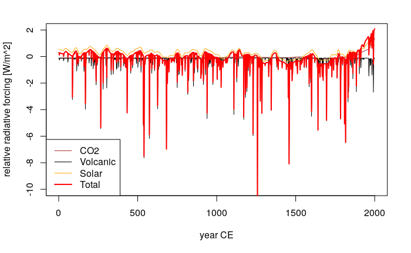

```r
matlines(RF$Year,RF$dR_CO2+RF$dR_Volc+RF$dR_TSI,col="red",lwd=2)
legend("bottomleft",c("CO2","Volcanic","Solar","Total"),col=c("brown","black","orange","red"),lty=rep(1,4),lwd=c(rep(1,3),2))
```

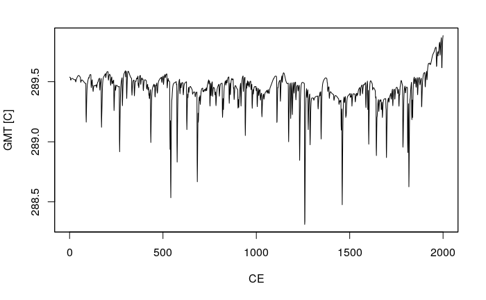

```r
rout<-getebm.0d(seq(-500,2000),Flux=cbind(RF$Year,RF$dR_Volc+RF$dR_TSI+RF$dR_CO2))
plot(rout$tsout,xlab="CE",ylab="GMT [C]")
```

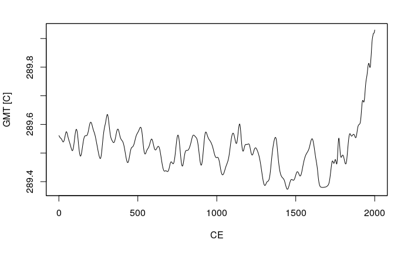

```r
rout<-getebm.0d(seq(-500,2000),Flux=cbind(RF$Year,RF$dR_TSI+RF$dR_CO2))
plot(rout$tsout,xlab="CE",ylab="GMT [C]")
```

```r
# rout<-getebm.0d(seq(-500,2000),Flux=cbind(RF$Year,RF$dR_CO2),plot=FALSE)
# plot(rout$tsout,xlab="CE",ylab="GMT [C]")
# rout<-getebm.0d(seq(-500,2000),Flux=cbind(RF$Year,RF$dR_TSI),plot=FALSE)
# plot(rout$tsout,xlab="CE",ylab="GMT [C]")
# rout<-getebm.0d(seq(-500,2000),Flux=cbind(RF$Year,RF$dR_Volc),plot=FALSE)
# plot(rout$tsout,xlab="CE",ylab="GMT [C]")
# rout<-getebm.0d(seq(-500,2000),Flux=cbind(RF$Year,RF$dR_Volc+RF$dR_TSI),plot=FALSE)
# plot(rout$tsout,xlab="CE",ylab="GMT [C]")
# as we are interested in the multidecadal timescale, adjust the heat capacity of the EBM by modifying the mid-layer depth of the ocean
heatcap.inv(tau=100)$h # effective water column depth
```

```
[1] 1049.991
```

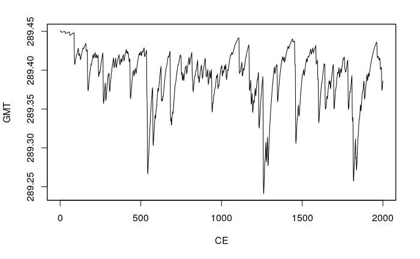

```r
parms<-list(f=0.7,h=1000,S=1365,eps=0.6,alpha=0.3)
rout_volc<-getebm.0d(Flux=cbind(RF$Year,RF$dR_Volc),seq(-500,2000),interp="linear",parms=parms,plot=FALSE)
plot(rout_volc$tsout,xlab="CE",ylab="GMT")
```

```r
rout_all<-getebm.0d(Flux=cbind(RF$Year,RF$dR_Volc+RF$dR_TSI+RF$dR_CO2),seq(-500,2000),interp="linear",parms=parms,plot=FALSE)
rout_novolc<-getebm.0d(Flux=cbind(RF$Year,RF$dR_TSI+RF$dR_CO2),seq(-500,2000),interp="linear",parms=parms,plot=FALSE)
rout_solar<-getebm.0d(Flux=cbind(RF$Year,RF$dR_TSI),seq(-500,2000),interp="linear",parms=parms,plot=FALSE)
rout_co2<-getebm.0d(Flux=cbind(RF$Year,RF$dR_CO2),seq(-500,2000),interp="linear",parms=parms,plot=FALSE)
```

```r
plot(rout_all$tsout,xlab="CE",ylab="GMT [C]",axes=FALSE,xlim=c(0,1850))
axis(1,at=seq(0,2000,by=100))
```

```r
axis(2)
lines(rout_novolc$tsout,col="blue")
```

```r
lines(rout_solar$tsout,col="orange")
lines(rout_co2$tsout,col="red")
```

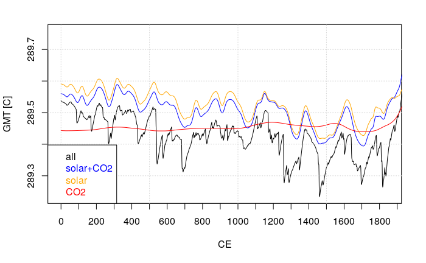

```r
grid()
legend("bottomleft",text.col=c("black","blue","orange","red"),c("all","solar+CO2","solar","CO2"))
```

FURTHER ANALYSIS IDEAS

Idea: Split the volcanic history into parts and generate a “high volcanic frequency” and a “low volcanic frequency” ensemble of forcing surrogates, that are each as long as the entire time series.

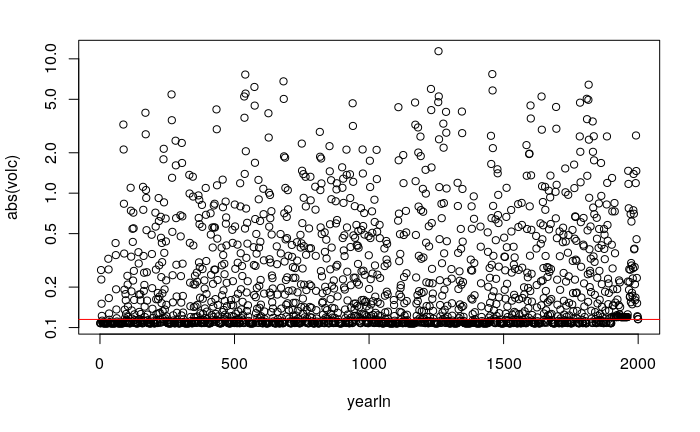

```r
##1 Volcanic frequency - split to get the high/low versions
#thresh<-0.005 # for AOD
#lowyears<-yearIn[which(volc>thresh)] #for AOD
volc<-RF$dR_Volc
thresh<- -0.115 # in W/m^2,
plot(yearIn,abs(volc),log="y")
abline(h=abs(thresh),col="red")
```

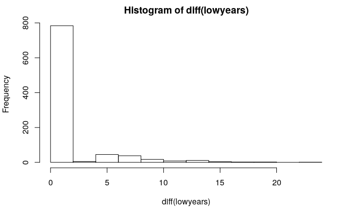

```r
lowyears<-yearIn[which(volc>thresh)] #for AOD
hist(diff(lowyears))
```

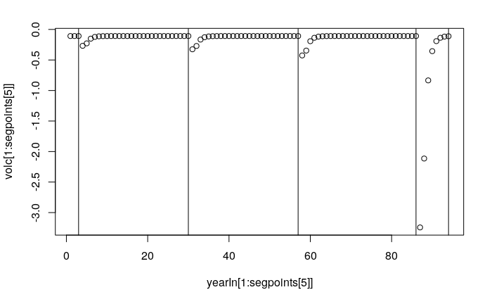

```r
# find those for which diff(lowyears) is more than 3 years to outline segments for permutation
segpoints<-lowyears[(diff(lowyears)>3)]
plot(yearIn[1:segpoints[5]],volc[1:segpoints[5]])
abline(v=segpoints)
```

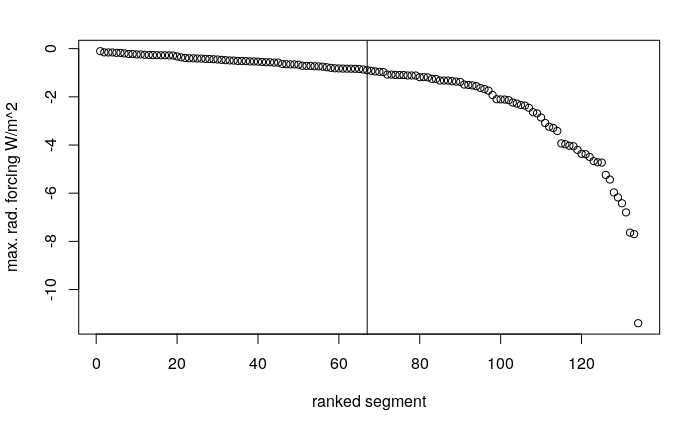

```r
#cumsum(yearIn%in%segpoints) # neat trick to split segments!
SP<-split(RF,cumsum(yearIn%in%segpoints)) # list of data frames with forcing
# get the maximum volcanic forcing (max for AOD, min for rel rad. Forcing)
volcmax<-(sapply(SP,function(x){min(x[['dR_Volc']])}))
ranking<-sort(volcmax,index.return=TRUE,decreasing=TRUE)$ix # decreasing for AOD
# find cutoff point to split high/low magnitude eruptions
plot(volcmax[ranking],xlab="ranked segment",ylab="max. rad. forcing W/m^2")
abline(v=length(SP)/2)
```

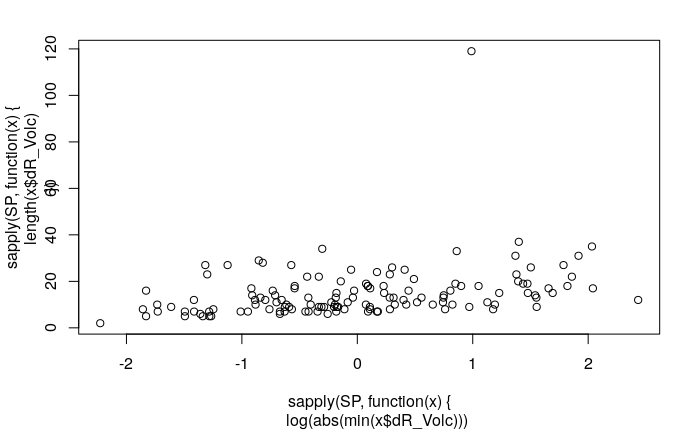

```r
# weak positive correlation between log max volc and duration of the interval
plot(sapply(SP,function(x){log(abs(min(x$dR_Volc)))}),sapply(SP,function(x){length(x$dR_Volc)}))
```

```r
## Ranked training sets to draw from - construct a high and a low magnitude version
SP.low<-(SP[ranking[1:(length(SP)/2)]])
SP.high<-(SP[ranking[(length(SP)/2+1):(length(SP))]])
```

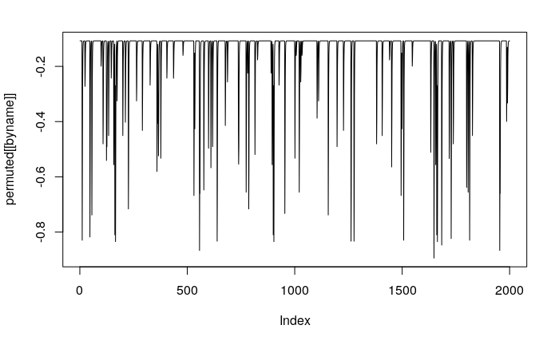

```r
pm<-drawfrom(SP,2000,plot=FALSE)
pm2<-drawfrom(SP.low,2000,plot=TRUE,repzero = 1)
```

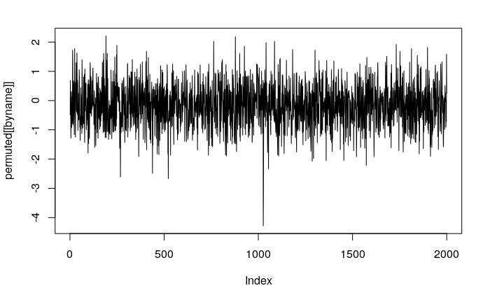

```r
pm3<-drawfrom(SP,2000,plot=TRUE,repzero=10,fixvarout = TRUE,targetvarout = var(RF$dR_Volc)+0.01)
```

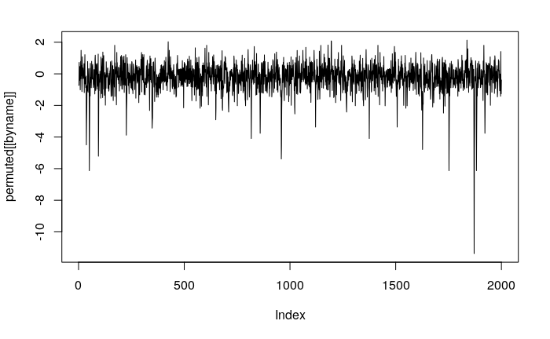

```r
pm3<-drawfrom(SP = SP,2000,plot=TRUE,repzero=1,fixvarout = TRUE,targetvarout = 0.8)
```

```r
# dQ<-rnorm(n = length(RF$dR_Volc),sd = sqrt(1-var(RF$dR_Volc)))
# > var(RF$dR_Volc+dQ)
plot(pm$dR_Volc,type="l")
lines(Ftab$dR_Volc,col="red")
```

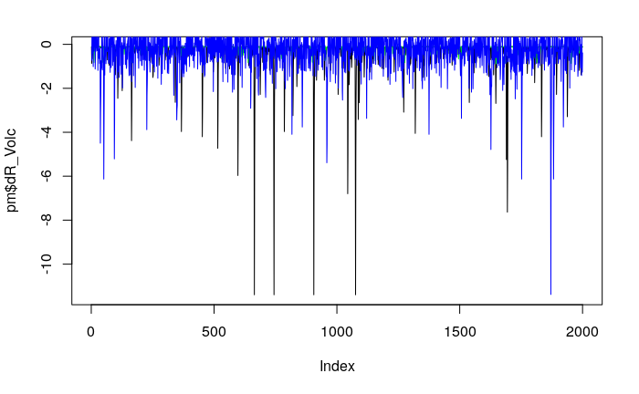

```r
lines(pm2$dR_Volc,col="green")
lines(pm3$dR_Volc,col="blue")
```

## get spectra

```r
# use sparse volcanic history pm2
parms<-list(f=0.7,h=1000,S=1365,eps=0.6,alpha=0.3)
rout_few<-getebm.0d(Flux=cbind(pm2$Year,pm2$dR_Volc),seq(-500,2000),interp="linear",parms=parms,plot=FALSE)
volccol<-"black"
tempcol<-"blue"
plot(rout_few$tsout,xlab="CE",ylab="GMT",col=tempcol,axes=FALSE)
axis(1)
```

```r
axis(2,col=tempcol,col.axis=tempcol)
par(new=TRUE)
```

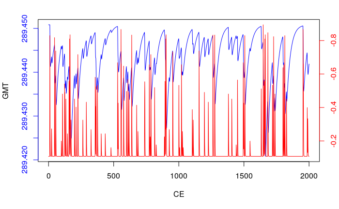

```r
plot(pm2$Year,pm2$dR_Volc,col="red",type="l",ylim=rev(range(pm2$dR_Volc)),axes=FALSE,xlab="",ylab="")
axis(4,col.axis="red",col="red")
```

```r
nmc<-1000
parms<-list(f=0.7,h=70,S=1365,eps=0.6,alpha=0.3)
FF<-c(seq(0,10,by=1),seq(12,20,by=2),c(25,30,40,50))
# FF<-c(seq(0,20,by=1),c(30,40,50,75,100))
FR<-rep(NA,length(FF))
Ftime<-seq(0,1000)
inttime<-seq(-500,1000)
tsc.in<-c(30,200)
RES.md<-as.data.frame(matrix(NA,ncol = nmc,nrow = length(FR)));
colnames(RES.md)<-paste("iter",seq(1,nmc))
row.names(RES.md)<-FF
RES.all<-FORC.all<-RES.md
exmpl<-vector(mode="list",length=length(FR))
getresponse<-function(VolcH,Ftime,inttime,parms){
  tmp<-getebm.0d(Flux=cbind(Ftime,VolcH),inttime,interp="linear",parms=parms,plot=FALSE)
  out<-coredata(tmp$tsout)
  rm(tmp)
  return(out)
}
##
for (i in 1:length(FF)){
  print(i)
  repzero<-FF[i]
  FMat<-replicate(nmc,drawfrom(SP,max(inttime),plot=FALSE,repzero=repzero,fixvarout = TRUE,targetvarout = var(RF$dR_Volc)+0.001)$dR_Volc)
  # if this is changed from SP to anything else, also replace the targetvarout variance for the TOA flux Q variance
  FORC.all[i,]<-apply(FMat,2,var)
  #LS.f<-apply(FMat,2,function(x,tsc.in){tsc_dep_var(zoo(x,order.by=Ftime),tsc.in)},tsc.in=tsc.in)

  exmpl[[i]]<-getebm.0d(Flux=cbind(Ftime,FMat[,1]),inttime,interp="linear",parms=parms,plot=FALSE)

  RMat<-apply(FMat,2,getresponse,Ftime=Ftime,inttime=inttime,parms=parms)

  LS<-apply(RMat,2,function(x,tsc.in){tsc_dep_var(zoo(x,order.by=Ftime),tsc.in)},tsc.in=tsc.in)


  # tot.var<-sapply(LS,function(x){x$var.tot})
  mdec.var<-sapply(LS,function(x){x$var.tsc})
  tot.var<-(apply(RMat,2,var)) # total variance
  RES.md[i,]<-mdec.var
  RES.all[i,]<-tot.var
  FR[i]<-mean(mdec.var)/mean(tot.var)
}
```

```
[1] 1
[1] 2
[1] 3
[1] 4
[1] 5
[1] 6
[1] 7
```

```r
##
for (i in 1:length(FF)){
  print(i)
  repzero<-FF[i]
  FMat<-replicate(nmc,drawfrom(SP,max(inttime),plot=FALSE,repzero=repzero,fixvarout = TRUE,targetvarout = var(RF$dR_Volc)+0.001)$dR_Volc)
  # if this is changed from SP to anything else, also replace the targetvarout variance for the TOA flux Q variance
  FORC.all[i,]<-apply(FMat,2,var)
  #LS.f<-apply(FMat,2,function(x,tsc.in){tsc_dep_var(zoo(x,order.by=Ftime),tsc.in)},tsc.in=tsc.in)

  exmpl[[i]]<-getebm.0d(Flux=cbind(Ftime,FMat[,1]),inttime,interp="linear",parms=parms,plot=FALSE)

  RMat<-apply(FMat,2,getresponse,Ftime=Ftime,inttime=inttime,parms=parms)

  LS<-apply(RMat,2,function(x,tsc.in){tsc_dep_var(zoo(x,order.by=Ftime),tsc.in)},tsc.in=tsc.in)


  # tot.var<-sapply(LS,function(x){x$var.tot})
  mdec.var<-sapply(LS,function(x){x$var.tsc})
  tot.var<-(apply(RMat,2,var)) # total variance
  RES.md[i,]<-mdec.var
  RES.all[i,]<-tot.var
  FR[i]<-mean(mdec.var)/mean(tot.var)
}
```

```r
i=1
j=7
cis<-varrat_ci(FR,rep(nmc*LS[[1]]$dof,length(FR)),rep(nmc*LS[[1]]$dof,length(FR)))
pdf(file=paste(outputdir, "multidec_ratio_volcforcing.pdf",sep=""),width=6,height=4)
  par(mar=c(3,3,1,1),cex=1.15,lwd=2)
  plot(FF,FR,xlab="",ylab="",ylim=range(cis),pch=20,col="black",bg="black",axes=FALSE,type="n")
arrows(x0 = FF,x1 = FF,y0=cis[,1],y1=cis[,2],length = 0.01,code = 3,angle=90)
points(FF,FR,pch=20,col="black",bg="black")
points(FF[c(i,j)],FR[c(i,j)],pch=20,col="indianred",bg="indianred")
# what is the average eruption epoch length?
axis(1,at=axTicks(1),labels=FALSE)
mtext(side=1,at=axTicks(1),text=axTicks(1),line=0.5)
axis(2,at=axTicks(2),labels=FALSE)
mtext(side=2,at=axTicks(2),text=axTicks(2),line=0.5)
mtext(side=1,font=2,line=2,"relative number of zero-eruption epochs")
mtext(side=2,font=2,line=1.5,expression(bold(paste(group("",{sigma[30-200]^2}/sigma[tot]^2,"")))))
box()
dev.off()
```

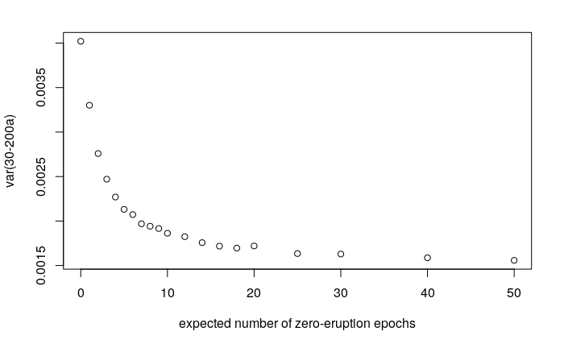

```r
plot(FF,apply(RES.md,1,mean),ylab="var(30-200a)",xlab="expected number of zero-eruption epochs")
```

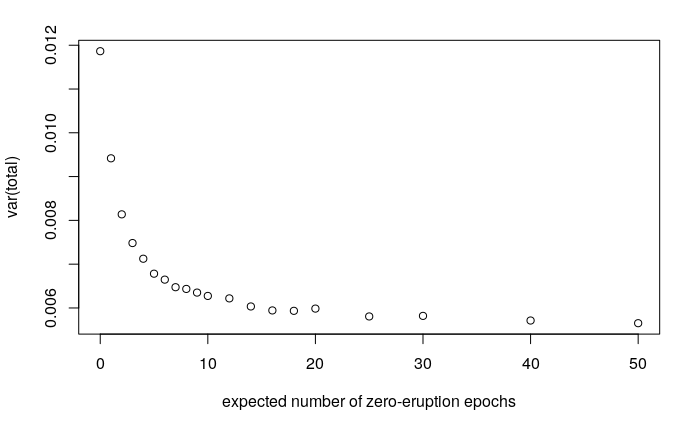

```r
plot(FF, apply(RES.all,1,mean),xlab="expected number of zero-eruption epochs",ylab="var(total)")
```

```r
# plotxx<-function(ts1,ts2,col1="black",col2="blue"){
#
# plot(ts1,col=col1,xlim=range(index(ts1),index(ts2)),ylim=range(ts1,ts2))
# lines(ts2,col=col2)
# }
#
# plotxx(exmpl[[1]]$tsout,exmpl[[3]]$tsout)
## plot forcing and response
tsx2<-exmpl[[j]]$tsout
tsy2<-zoo(exmpl[[j]]$forcing.ts,order.by=index(exmpl[[j]]$tsout))
for (k in c(1,7,20)){
pdf(file=paste(outputdir,"ts_",k,".pdf",sep=""),width=6,height=4)
  yax2=FALSE
par(mar=c(4,4,1,4),cex=1.15,lwd=2,cex.lab=1.15)
tsx1<-exmpl[[k]]$tsout
tsy1<-zoo(exmpl[[k]]$forcing.ts,order.by=index(exmpl[[k]]$tsout))
if (k>6) yax2=seq(-3,0)
plotxy(tsx1,tsy1,col1="black",ylimy1=c(-1,0.2))
dev.off()
}
# plotxy(tsx2,tsy2,col1="black")
# in principle, the variance of the forcing is to a value slightly higher than in the original volcanic forcing, but drawing only one realization for each recurrence strengths, the effective forcing strength varies slightly.
#plot(sapply(exmpl,function(x){var(x$forcing.ts)}),sapply(exmpl,function(x){var(x$tsout)}))
```

** TO BE DONE** ## more systematically: get variances of the forcing ts and variance of the responses ## check that the forcing variance is always the same ## get the response for a systematic range ## get quantiles and dual plots for the examples ## look at the spectra of forcing and response ## read up on spectral gain ## plot decadal vs. total variance <—————————– I think that’s the key point

# boxplot(log10(yonkers), log10(stamford),names = c(“Yonkers”, “Stamford”),main = “New York Ozone Levels”,ylab = “Log10 Ozone Levels (ppb)”,notch = TRUE)

# rout_few<-getebm.0d(Flux=cbind(pm2$Year,VolcH),seq(-500,2000),interp=“linear”,parms=parms,plot=FALSE)